# Modelación ARMA de la temperatura de un motor eléctrico

Ana Gundermann

2026-07-02

# Introducción

La temperatura del bobinado (`stator_winding`) es una variable relevante para describir el comportamiento térmico de un motor eléctrico durante su funcionamiento.

En este trabajo se estudia su evolución temporal durante el régimen permanente del motor, utilizando datos reales obtenidos desde un banco de pruebas disponible en Kaggle.

El objetivo es evaluar si un modelo ARMA permite representar adecuadamente esta serie temporal y generar predicciones de corto plazo.

# Objetivos

## Objetivo general

Evaluar la factibilidad de modelar la evolución temporal de la temperatura del bobinado de un motor eléctrico mediante un modelo ARMA, utilizando datos reales.

## Objetivos específicos

- Analizar la evolución temporal de la temperatura durante el régimen permanente del motor.
- Verificar la estacionariedad de la serie de tiempo.
- Proponer y comparar modelos ARMA candidatos mediante ACF, PACF y AIC.
- Validar el modelo seleccionado mediante el análisis de residuos (Ljung-Box).

# Base de datos

Se utilizó el conjunto de datos **Electric Motor Temperature**, disponible en Kaggle. La base contiene mediciones obtenidas desde un banco de pruebas de motores eléctricos bajo distintas condiciones de funcionamiento.

La variable principal utilizada fue `stator_winding`, correspondiente a la temperatura del bobinado del estator. Además, se utilizó `torque` como variable auxiliar para identificar el inicio del enfriamiento.

| Caracteristica | Valor |
| --- | --- |
| Fuente | https://www.kaggle.com/datasets/wkirgsn/electric-motor-temperature |
| Observaciones totales | 1330816 |
| Número de variables | 13 |
| Número de perfiles | 69 |
| Perfil seleccionado | 13 |
| Observaciones del perfil 13 | 35906 |
| Variable principal | stator_winding |
| Variable auxiliar | torque |

## Preparación de la serie de tiempo

En esta etapa se seleccionó el tramo correspondiente al régimen térmico estable del motor. Para ello se utilizaron dos variables:

- `torque`: para detectar el fin de carga.
- `stator_winding`: para detectar el inicio del régimen estable.

Primero se identificó el instante en que el torque cae a valores cercanos a cero. Este punto marca el fin de carga del motor.

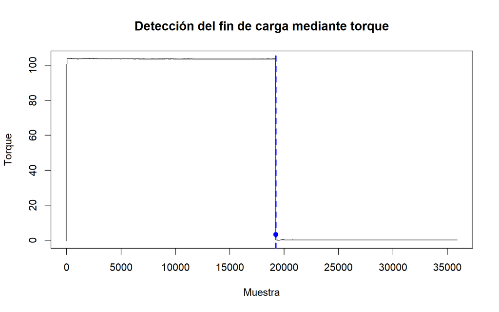

Luego se estimó una temperatura de referencia para el régimen estable. Para esto se utilizó el promedio de los últimos 5 minutos antes del fin de carga. También se estimó la temperatura inicial usando el promedio del primer minuto del perfil.

A partir de esos valores, se calculó el aumento total de temperatura y se definió como inicio del régimen estable el primer instante en que la media móvil alcanza el 99% de dicho aumento.

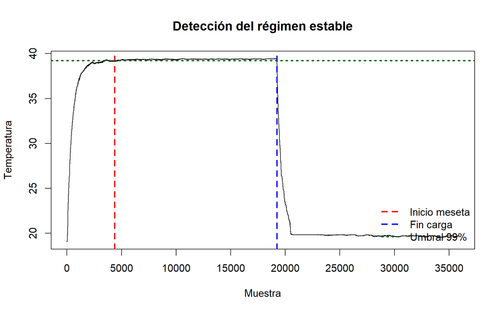

Finalmente, se extrajo la meseta térmica comprendida entre el inicio del régimen estable y el fin de carga. Este tramo será utilizado para el análisis de series de tiempo.

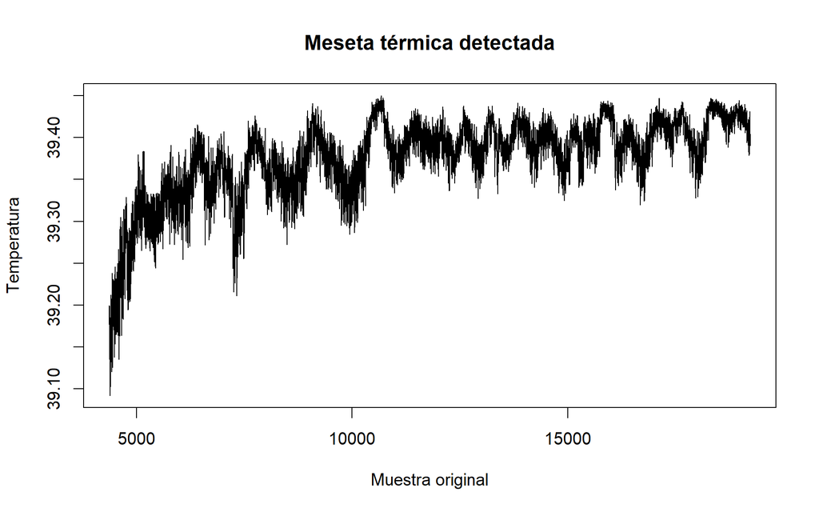

Resumen del procedimiento de preparación de la serie.

| Paso | Procedimiento |
| --- | --- |
| 1 | Selección del Profile 13 para el análisis. |
| 2 | Uso de la serie original registrada a 2 Hz. |
| 3 | Detección del fin de carga mediante torque. |
| 4 | Estimación de la temperatura inicial con el primer minuto. |
| 5 | Estimación de la temperatura de referencia con los últimos 5 minutos antes del fin de carga. |
| 6 | Detección del inicio del régimen estable cuando la media móvil alcanza el 99% del aumento total. |
| 7 | Extracción de la meseta térmica para el análisis. |

Características de la meseta térmica seleccionada.

| Caracteristica | Valor |
| --- | --- |
| Inicio de la meseta | 4373 |
| Fin de la meseta | 19230 |
| Número de observaciones | 14858 |
| Frecuencia de muestreo | 2 Hz (1 dato cada 0.5 s) |
| Duración | 7429.0 s |
| Temperatura mínima (°C) | 39.092 |
| Temperatura máxima (°C) | 39.45 |
| Rango térmico (°C) | 0.358 |

# 4 Estudio de la estacionariedad

La serie correspondiente al régimen térmico estable fue analizada mediante el test Dickey-Fuller aumentado (ADF), con el propósito de verificar si presenta evidencia estadística de estacionariedadd.

Hipótesis del test:

- **H₀:** La serie no es estacionaria.
- **H₁:** La serie es estacionaria.

```
##
##  Augmented Dickey-Fuller Test
##
## data:  meseta
## Dickey-Fuller = -7.0621, Lag order = 24, p-value = 0.01
## alternative hypothesis: stationary
```

Resultados del test Dickey-Fuller aumentado.

|  | Estadistico | p.value |
| --- | --- | --- |
| Dickey-Fuller | -7.0621 | 0.01 |

### Conclusión

Como el valor-p obtenido fue inferior al nivel de significancia de 0.05, se rechazó la hipótesis nula. Por lo tanto, se concluye que la serie correspondiente al régimen térmico estable presenta evidencia de estacionariedad. En consecuencia, resulta apropiado continuar con el análisis de su estructura temporal mediante las funciones de autocorrelación (ACF) y autocorrelación parcial (PACF), con el fin de identificar modelos candidatos para la identificación del modelo.

# Identificación del modelo

## Funciones ACF y PACF

Con el fin de estudiar la estructura temporal de la serie estacionaria, se analizaron las funciones de autocorrelación (ACF) y autocorrelación parcial (PACF) correspondientes a la meseta térmica.

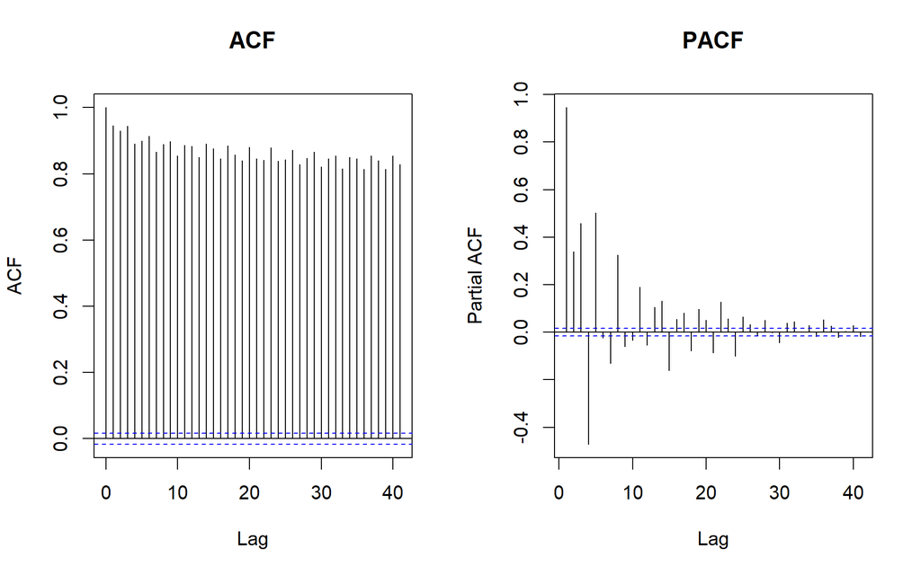

Figura 5. Funciones ACF y PACF de la meseta térmica.

### Interpretación

| Función | Observación | Interpretación |
| --- | --- | --- |
| ACF | Decae lentamente y mantiene autocorrelaciones elevadas en numerosos retardos. | Existe una fuerte dependencia entre observaciones consecutivas. |
| PACF | Presenta varios retardos significativos sin un corte claramente definido. | La identificación visual del orden autorregresivo resulta ambigua. |

### Interpretación de ACF y PACF

La **función de autocorrelación (ACF)** presenta un decaimiento gradual muy lento y mantiene valores elevados en un gran número de retardos. Esto indica una fuerte dependencia temporal entre observaciones consecutivas, comportamiento esperable debido a que la temperatura fue registrada con una frecuencia de **2 Hz** (una observación cada 0.5 segundos), mientras que la evolución térmica del motor ocurre a una escala temporal considerablemente más lenta.

Por su parte, la función de autocorrelación parcial (PACF) presenta varios retardos significativos y no exhibe un corte claramente definido. En consecuencia, la identificación visual del orden autorregresivo resulta poco concluyente.

En estas condiciones, la interpretación visual de ambos correlogramas resulta poco concluyente para seleccionar un modelo parsimonioso. Por esta razón, se decidió realizar un **submuestreo temporal**, conservando una observación cada **10 segundos**. Esta estrategia mantiene el comportamiento global de la serie, pero reduce la redundancia entre observaciones consecutivas, obteniendo correlogramas más informativos para la identificación del modelo.

# Submuestreo de la serie

Con el propósito de obtener correlogramas más informativos para la identificación del modelo, se realizó un submuestreo temporal sobre la meseta térmica.

Dado que la frecuencia original de adquisición fue de **2 Hz**, se conservó una observación cada **20 muestras**, equivalente a una observación cada **10 segundos**.

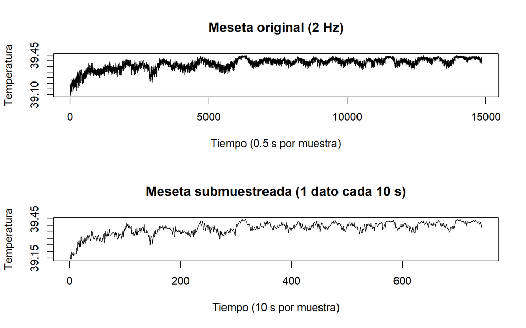

Figura 6. Comparación entre la serie original y la serie submuestreada.

La serie submuestreada conserva el comportamiento general observado en la serie original, pero reduce el número de observaciones altamente correlacionadas, facilitando la interpretación de las funciones de autocorrelación y autocorrelación parcial.

Resumen del submuestreo aplicado.

| Característica | Valor |
| --- | --- |
| Observaciones originales | 14858 |
| Observaciones submuestreadas | 743 |
| Frecuencia original | 2 Hz (1 dato cada 0.5 s) |
| Frecuencia submuestreada | 1 dato cada 10 s |

# Verificación de la estacionariedad de la serie submuestreada

Con el propósito de verificar que el submuestreo no alteró las propiedades estadísticas de la serie, se aplicó nuevamente el test Dickey-Fuller aumentado (ADF) sobre la serie submuestreada.

Hipótesis del test:

- **H₀:** La serie no es estacionaria.
- **H₁:** La serie es estacionaria.

```
##
##  Augmented Dickey-Fuller Test
##
## data:  meseta_10s
## Dickey-Fuller = -6.8844, Lag order = 9, p-value = 0.01
## alternative hypothesis: stationary
```

Resultados del test Dickey-Fuller aumentado para la serie submuestreada.

|  | Estadístico | Valor.p |
| --- | --- | --- |
| Dickey-Fuller | -6.8844 | 0.01 |

### Conclusión

Como el valor-p obtenido fue inferior al nivel de significancia de 0.05, se rechazó la hipótesis nula. En consecuencia, existe evidencia estadística de que la serie submuestreada es **estacionaria**. Esto indica que el submuestreo permitió reducir la redundancia temporal entre observaciones sin modificar la naturaleza estacionaria de la serie, por lo que resulta apropiado utilizarla para la identificación y ajuste del modelo ARMA.

# Identificación del modelo

## Funciones ACF y PACF

Una vez realizado el submuestreo y verificada la estacionariedad de la serie resultante, se analizaron nuevamente las funciones de autocorrelación (ACF) y autocorrelación parcial (PACF), con el propósito de identificar modelos candidatos para describir la dependencia temporal de la serie.

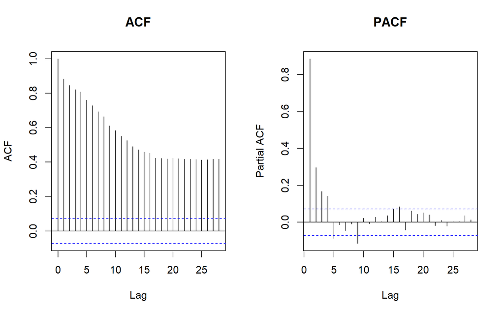

Figura 7. Funciones ACF y PACF de la serie submuestreada.

## Interpretación

| Función | Observación | Interpretación |
| --- | --- | --- |
| ACF | Decae gradualmente sin presentar un corte abrupto. | Descarta un modelo MA puro y sugiere una componente autorregresiva. |
| PACF | Los primeros retardos son significativos y luego disminuyen considerablemente. | Sugiere un modelo autorregresivo de bajo orden. |

La **ACF** presenta un decaimiento gradual, indicando que la dependencia temporal disminuye progresivamente conforme aumenta el retardo. Este comportamiento descarta un modelo de media móvil puro y sugiere la presencia de una componente autorregresiva.

Por su parte, la **PACF** presenta retardos significativos principalmente en los primeros lags, observándose posteriormente una disminución importante. Este patrón es consistente con un proceso autorregresivo de bajo orden.

Considerando conjuntamente ambos correlogramas, se seleccionaron diversos modelos ARMA de bajo orden como candidatos para representar la serie.

# Ajuste de modelos candidatos

## Modelos candidatos

De acuerdo con la inspección de las funciones ACF y PACF, se ajustaron distintos modelos ARMA de bajo orden. La selección consideró tanto modelos puramente autorregresivos como modelos mixtos, con el objetivo de comparar diferentes estructuras de dependencia temporal.

## Significancia de los coeficientes

La significancia estadística de los coeficientes de cada modelo se evaluó mediante el estadístico

$$z = \frac{\widehat{\beta}}{SE(\widehat{\beta})}.$$

Bajo una aproximación normal, se considera significativo un coeficiente cuando

$$|z| > 1.96.$$

Resumen de significancia de los coeficientes.

|  | Modelo | Todos_significativos |
| --- | --- | --- |
| ARMA(1,0) | ARMA(1,0) | TRUE |
| ARMA(2,0) | ARMA(2,0) | TRUE |
| ARMA(3,0) | ARMA(3,0) | TRUE |
| ARMA(4,0) | ARMA(4,0) | TRUE |
| ARMA(5,0) | ARMA(5,0) | FALSE |
| ARMA(1,1) | ARMA(1,1) | TRUE |
| ARMA(2,1) | ARMA(2,1) | FALSE |
| ARMA(3,1) | ARMA(3,1) | FALSE |
| ARMA(2,2) | ARMA(2,2) | TRUE |
| ARMA(3,2) | ARMA(3,2) | TRUE |

Se consideraron adecuados aquellos modelos cuyos coeficientes resultaron estadísticamente significativos.

## Comparación mediante AIC

El criterio de información de Akaike (AIC) permite comparar modelos considerando simultáneamente la calidad del ajuste y la complejidad del modelo. Se prefiere el modelo con menor valor de AIC, privilegiando modelos que ofrecen buen ajuste sin incorporar parámetros innecesarios.

Comparación de modelos mediante AIC.

|  | Modelo | AIC |
| --- | --- | --- |
| ARMA(5,0) | ARMA(5,0) | -3780.679 |
| ARMA(4,0) | ARMA(4,0) | -3780.217 |
| ARMA(3,2) | ARMA(3,2) | -3778.846 |
| ARMA(2,2) | ARMA(2,2) | -3771.234 |
| ARMA(3,1) | ARMA(3,1) | -3767.421 |
| ARMA(1,1) | ARMA(1,1) | -3764.003 |
| ARMA(2,1) | ARMA(2,1) | -3761.981 |
| ARMA(3,0) | ARMA(3,0) | -3753.720 |
| ARMA(2,0) | ARMA(2,0) | -3708.823 |
| ARMA(1,0) | ARMA(1,0) | -3608.191 |

## Selección del modelo

Entre los modelos cuyos coeficientes resultaron estadísticamente significativos, el modelo **ARMA(4,0)** obtuvo el mejor compromiso entre calidad de ajuste y simplicidad estructural.

Aunque modelos de mayor orden o modelos mixtos pueden alcanzar valores de AIC cercanos, éstos incorporan una mayor cantidad de parámetros. En particular, el modelo **ARMA(5,0)** fue evaluado, pero no se seleccionó debido a que el quinto coeficiente autorregresivo no resultó significativo.

Por estas razones, el modelo **ARMA(4,0)** fue seleccionado para el análisis de residuos y la validación final del ajuste.

```
##
## Call:
## arima(x = meseta_10s, order = c(4, 0, 0))
##
## Coefficients:
##          ar1     ar2     ar3     ar4  intercept
##       0.4443  0.1822  0.1583  0.1969    39.3614
## s.e.  0.0360  0.0391  0.0393  0.0365     0.0333
##
## sigma^2 estimated as 0.0003541:  log likelihood = 1896.11,  aic = -3780.22
```

# Diagnóstico de residuos

Un modelo ARMA adecuadamente ajustado debe producir residuos compatibles con **ruido blanco**, es decir, residuos sin autocorrelación, con media cercana a cero y varianza aproximadamente constante. Si los residuos presentan estructura temporal, el modelo no describe completamente la dinámica de la serie.

## ACF y PACF de los residuos

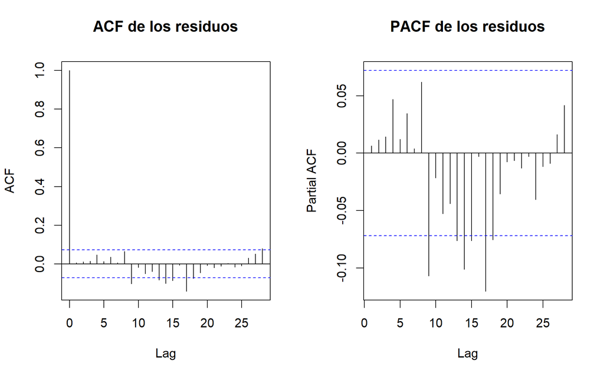

Figura 8. Funciones ACF y PACF de los residuos del modelo ARMA(4,0).

## Diagnóstico del modelo

El diagnóstico del modelo se realizó mediante la función `tsdiag`, la cual resume tres aspectos fundamentales del comportamiento de los residuos:

- **Residuos estandarizados:** permiten verificar visualmente si los residuos fluctúan aleatoriamente alrededor de cero y si mantienen una varianza aproximadamente constante a lo largo del tiempo.
- **Función ACF de los residuos:** permite comprobar si persiste autocorrelación después del ajuste del modelo. Idealmente, las autocorrelaciones deben encontrarse dentro de las bandas de confianza.
- **Valores-p del test de Ljung-Box:** muestran el resultado del test para distintos retardos. Valores-p superiores a 0.05 indican que no existe evidencia suficiente para rechazar la hipótesis de ausencia de autocorrelación.

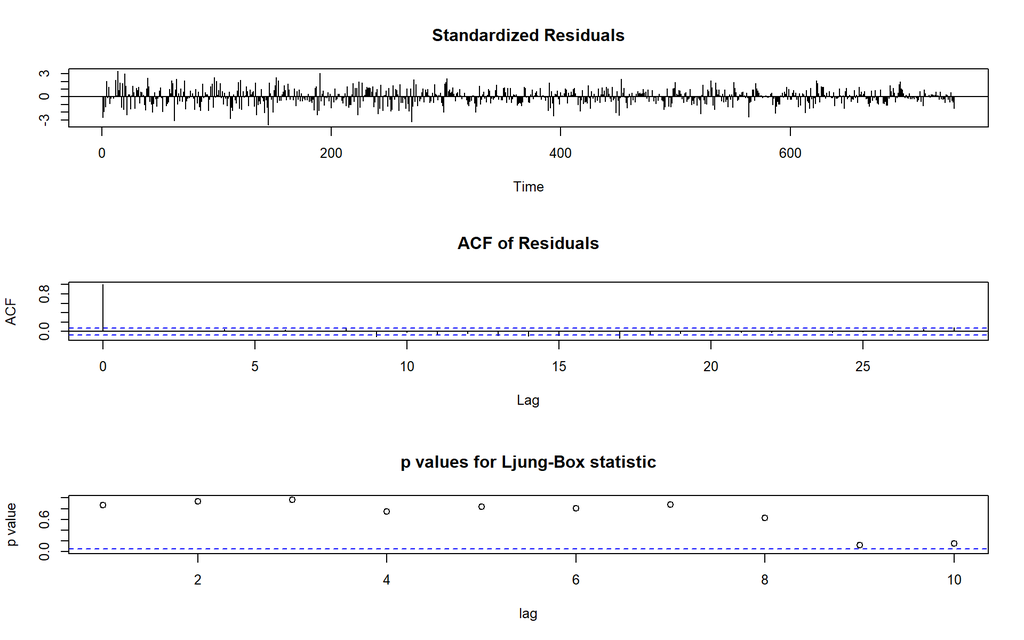

Figura 9. Diagnóstico del modelo ARMA(4,0).

## Test de Ljung-Box

Para verificar formalmente la ausencia de autocorrelación en los residuos se aplicó el test de Ljung-Box.

Hipótesis:

- **H₀:** Los residuos no presentan autocorrelación.
- **H₁:** Los residuos presentan autocorrelación.

```
## Ljung-Box (lag = 1)
```

```
##
##  Box-Ljung test
##
## data:  residuals(modelo_final)
## X-squared = 0.030634, df = 1, p-value = 0.8611
```

```
##
##
## Ljung-Box (lag = 10)
```

```
##
##  Box-Ljung test
##
## data:  residuals(modelo_final)
## X-squared = 14.49, df = 10, p-value = 0.1518
```

Resultados del test de Ljung-Box.

| Lag | Estadístico | Valor.p |
| --- | --- | --- |
| 1 | 0.0306 | 0.8610585 |
| 10 | 14.4900 | 0.1517915 |

### Conclusión

En ambos retardos evaluados el valor-p fue superior al nivel de significancia de 0.05. En consecuencia, no se rechazó la hipótesis nula y los residuos pueden considerarse compatibles con un proceso de ruido blanco.

## Normalidad de los residuos

Además de la ausencia de autocorrelación, se evaluó la normalidad de los residuos mediante inspección gráfica y el test de Shapiro-Wilk.

### Análisis gráfico

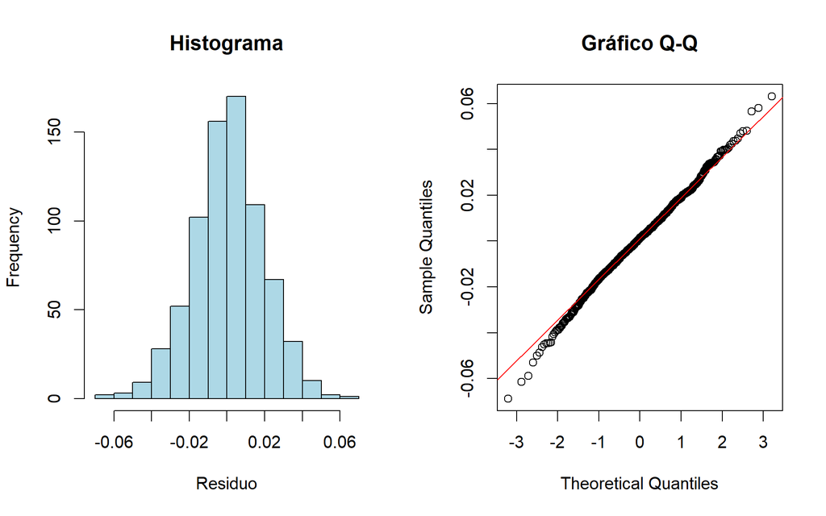

Figura 10. Histograma y gráfico Q-Q de los residuos.

### Tests de normalidad

Con el objetivo de evaluar la normalidad de los residuos del modelo, se aplicaron los tests de Shapiro-Wilk y Jarque-Bera.

Hipótesis:

- **H₀:** Los residuos siguen una distribución normal.
- **H₁:** Los residuos no siguen una distribución normal.

```
##
##  Shapiro-Wilk normality test
##
## data:  residuals(modelo_final)
## W = 0.99683, p-value = 0.1502
```

```
##
##  Jarque Bera Test
##
## data:  residuals(modelo_final)
## X-squared = 7.7462, df = 2, p-value = 0.02079
```

### Conclusión

El test de **Shapiro-Wilk** entregó un valor-p superior a 0.05, por lo que no se rechazó la hipótesis nula de normalidad. Por otra parte, el test de **Jarque-Bera** detectó ligeras desviaciones respecto de una distribución normal, atribuibles a pequeñas diferencias en la asimetría o la curtosis de los residuos.

En conjunto con el histograma y el gráfico Q-Q, se concluye que los residuos presentan un comportamiento **aproximadamente normal**, aunque existen leves desviaciones detectadas por el test de Jarque-Bera.

En conjunto, los resultados obtenidos indican que el modelo **ARMA(4,0)** proporciona un ajuste adecuado para la serie analizada, ya que los residuos no presentan evidencia de autocorrelación y son compatibles con una distribución aproximadamente normal.

# Modelo final

Una vez verificado que los residuos del modelo seleccionado son compatibles con un proceso de ruido blanco y presentan un comportamiento aproximadamente normal, se adopta el modelo **ARMA(4,0)** como representación final de la serie.

## 11.1 Representación general

Sea

$$Y_t=X_t-\mu,$$

donde $\mu$ representa la media del proceso. Entonces, un modelo ARMA$(p,q)$ puede escribirse como

$$Y_t
=
\sum_{i=1}^{p}\phi_iY_{t-i}
+
\varepsilon_t
+
\sum_{j=1}^{q}\theta_j\varepsilon_{t-j},
\qquad
\varepsilon_t\sim WN(0,\sigma^2).$$

donde:

- $Y_t$ representa la serie centrada alrededor de la media;
- $\phi_i$ son los coeficientes autorregresivos;
- $\theta_j$ son los coeficientes de media móvil;
- $\varepsilon_t$ corresponde a un proceso de ruido blanco con media cero y varianza constante.

Como el modelo seleccionado corresponde a un **ARMA(4,0)**, no posee componente de media móvil. En consecuencia,

$$Y_t
=
\sum_{i=1}^{4}\phi_iY_{t-i}
+
\varepsilon_t,
\qquad
\varepsilon_t\sim WN(0,\sigma^2).$$

## Coeficientes estimados

Coeficientes estimados del modelo ARMA(4,0).

|  | Parametro | Estimacion |
| --- | --- | --- |
| ar1 | ar1 | 0.44429 |
| ar2 | ar2 | 0.18223 |
| ar3 | ar3 | 0.15831 |
| ar4 | ar4 | 0.19691 |
| intercept | intercept | 39.36137 |

## Modelo ajustado

En el ajuste realizado con `arima()` de R para un modelo ARMA con $d=0$, el término reportado como `intercept` corresponde al nivel medio estimado de la serie. Por lo tanto, la ecuación ajustada se escribe centrada alrededor de dicha media.

$$Y_t = 0.44429Y_{t-1} + 0.18223Y_{t-2} + 0.15831Y_{t-3} + 0.19691Y_{t-4}
+ \varepsilon_t$$

donde $Y_t=X_t-\mu$, con $\mu=39.3614$.

El modelo obtenido indica que la temperatura del estator fluctúa alrededor de una media estimada y que sus desviaciones respecto de esa media dependen linealmente de las cuatro observaciones anteriores.

# Predicción

Una vez validado el modelo **ARMA(4,0)**, se realizó una predicción de corto plazo sobre la serie submuestreada. El objetivo es proyectar el comportamiento esperado de la temperatura en el régimen térmico estable.

```
##     Point Forecast    Lo 80    Hi 80    Lo 95    Hi 95
## 744       39.39851 39.37439 39.42263 39.36163 39.43539
## 745       39.39798 39.37159 39.42437 39.35762 39.43834
## 746       39.39559 39.36766 39.42352 39.35287 39.43831
## 747       39.39293 39.36332 39.42255 39.34764 39.43823
## 748       39.39474 39.36260 39.42688 39.34559 39.44389
## 749       39.39457 39.36064 39.42851 39.34267 39.44648
## 750       39.39394 39.35842 39.42946 39.33962 39.44826
## 751       39.39339 39.35634 39.43044 39.33672 39.45005
## 752       39.39336 39.35477 39.43195 39.33434 39.45237
## 753       39.39311 39.35311 39.43311 39.33194 39.45428
## 754       39.39278 39.35146 39.43410 39.32959 39.45598
## 755       39.39248 39.34989 39.43507 39.32735 39.45761
```

Como la serie fue submuestreada cada **10 segundos**, una predicción de $h=12$ pasos corresponde a los siguientes **120 segundos**, es decir, aproximadamente **2 minutos**.

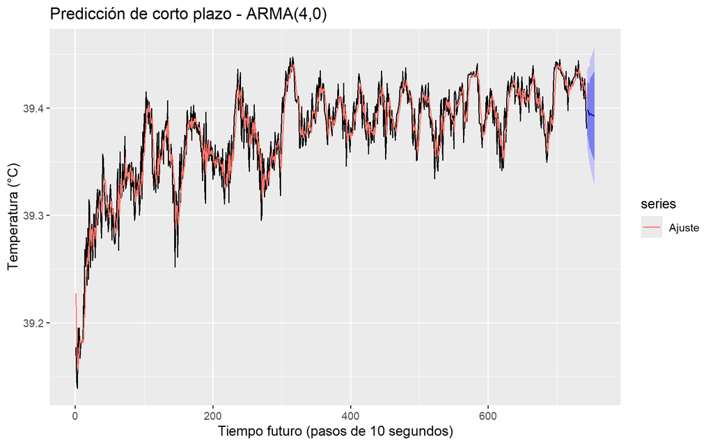

Figura 11. Predicción de corto plazo mediante el modelo ARMA(4,0).

Predicción de temperatura para los próximos 12 pasos.

| Paso | Tiempo | Prediccion | LI_80 | LS_80 | LI_95 | LS_95 |
| --- | --- | --- | --- | --- | --- | --- |
| 1 | 10 s | 39.39851 | 39.37439 | 39.42263 | 39.36163 | 39.43539 |
| 2 | 20 s | 39.39798 | 39.37159 | 39.42437 | 39.35762 | 39.43834 |
| 3 | 30 s | 39.39559 | 39.36766 | 39.42352 | 39.35287 | 39.43831 |
| 4 | 40 s | 39.39293 | 39.36332 | 39.42255 | 39.34764 | 39.43823 |
| 5 | 50 s | 39.39474 | 39.36260 | 39.42688 | 39.34559 | 39.44389 |
| 6 | 60 s | 39.39457 | 39.36064 | 39.42851 | 39.34267 | 39.44648 |
| 7 | 70 s | 39.39394 | 39.35842 | 39.42946 | 39.33962 | 39.44826 |
| 8 | 80 s | 39.39339 | 39.35634 | 39.43044 | 39.33672 | 39.45005 |
| 9 | 90 s | 39.39336 | 39.35477 | 39.43195 | 39.33434 | 39.45237 |
| 10 | 100 s | 39.39311 | 39.35311 | 39.43311 | 39.33194 | 39.45428 |
| 11 | 110 s | 39.39278 | 39.35146 | 39.43410 | 39.32959 | 39.45598 |
| 12 | 120 s | 39.39248 | 39.34989 | 39.43507 | 39.32735 | 39.45761 |

La predicción muestra que, bajo el supuesto de continuidad del régimen térmico estable, la temperatura esperada se mantiene cercana al nivel medio estimado por el modelo. Esto es coherente con el comportamiento observado en la meseta, donde la temperatura presenta pequeñas fluctuaciones alrededor de un equilibrio térmico.

# Bibliografía

- Box, G. E. P., Jenkins, G. M., & Reinsel, G. C. (2013). *Time Series Analysis: Forecasting and Control* (5th ed.). John Wiley & Sons.
- Material docente del curso *Series de Tiempo*. Taller: Análisis Completo de Series de Tiempo con Modelos ARMA/ARIMA. Profesor Cristian Meza. Universidad de Valparaíso, 2026.
- Material docente del curso *Series de Tiempo*. Taller: Identificación, Ajuste y Predicción de Modelos AR y MA. Profesor Cristian Meza. Universidad de Valparaíso, 2026.
- IBM. (2024). *Downsampling*. https://www.ibm.com/think/topics/downsampling
- Future Forecasting. (s.f.). *Temporal Aggregation*. https://www.future-forecasting.de/en/wiki/zeitliche_aggregation/